# Tips on Building Shiny Apps

Elgar Teo

May 03, 2021

Shiny is a powerful framework that allows you to create interactive web applications using just the R language. Though there are some common pitfalls/hassles when building Shiny applications. This guide aims to help you avoid them.

# Formatting

Since it is very likely that your code would be in a nested structure that involves a bunch of parentheses one inside another, it is not uncommon for one to encounter to following error message when developing a Shiny app:

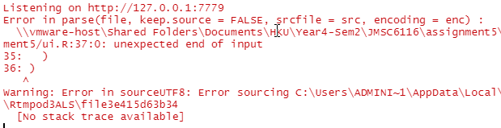

This `Error in sourcing` message likely indicates that there are some extra or missing symbols in your code like an redundant comma (e.g., `fluidRow(uiOutput("header"), uiOutput("post_c"),)`) or a missing closing parenthesis (e.g., `fluidRow(uiOutput("header"), uiOutput("post_c")`).

Keeping the formatting of your code clean can help avoid this type of error. Imagine that you want to construct a Shiny app that comprises of two rows with two and three boxes respectively:

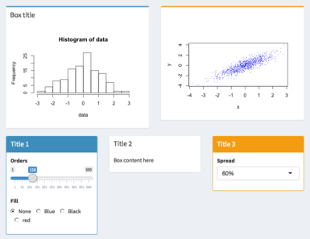

```r
## Version A:
ui <- dashboardPage(dashboardHeader(title = "Row layout"),dashboardSidebar(),
  dashboardBody(fluidRow(box(title = "Box title", "Box content"),box(status = "warning", "Box content")),
fluidRow(
box(title = "Title 1", width = 4, solidHeader = TRUE, status = "primary","Box content"),box(title = "Title 2", width = 4, solidHeader = TRUE,"Box content"
),box(title = "Title 1", width = 4, solidHeader = TRUE, status = "warning","Box content"))))

## Version B
ui <- dashboardPage(
  dashboardHeader(title = "Row layout"),
  dashboardSidebar(),
  dashboardBody(
    fluidRow(
      box(title = "Box title", "Box content"),
      box(status = "warning", "Box content")
    ),

    fluidRow(
      box(
        title = "Title 1", width = 4, solidHeader = TRUE, status = "primary",
        "Box content"
        ),
      box(
        title = "Title 2", width = 4, solidHeader = TRUE,
        "Box content"
      ),
      box(
        title = "Title 1", width = 4, solidHeader = TRUE, status = "warning",
        "Box content"
      )
    )
  )
)
```

Both versions work. But Version B is apparently easier to comprehend as you can easily tell that the structure of the interface. In contrast, version A is just a mess. Worse of all, if you carelessly mistyped an extra comma or forgot a closing parenthesis, it would be immensely difficult for you to track down the culprit of the error.

From the example above, we can derive several rules in formatting:

1. If you are to insert a long section of code into a parenthesis, do so in an indented new line.
2. If there are way too many parameters inside a function, split them into multiple lines.
3. Always end a line with `(`, `)` or `,`.

Following these rules is easier than you think. RStudio’s editor automatically indents the code so you can easily format your code just by using the Backspace and Enter key:

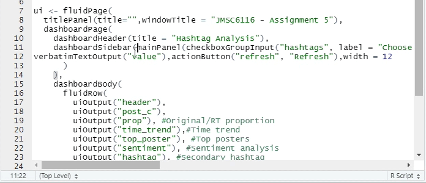

Another useful feature of RStudio is its ability to track the pairs of parenthesis. When you place the text cursor right after a parenthesis, the corresponding paired parenthesis will be highlighted:

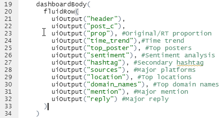

This can help you avoid missing parenthesis.

# `shinydashboard`

In the class, we introduced `shinydashboard`, a package that offers an easy-to-use framework for building Shiny apps. The `fluidRow()` function that arranges UI components in row and the `valueBoxOutput()/renderValueBox()` functions that render “value boxes” are part of the features provided by `shinydashboard`.

We only managed to scratch on the surface of `shinydashboard` in the class. If you are interested in implementing other features provided by the package such as a column-based layout and “info boxes”, you can refer to its very intuitive documentation [here](https://rstudio.github.io/shinydashboard/index.html).

# Ploting graphs

In the in-class example, we introduced the way to plot Plotly graphs using the `plotlyOutput()/renderPlotly()` functions. Beside Plotly graphs, you can also incorporate other graphics such as word cloud or `leaflet` maps into a Shiny app.

To understand how to insert graphics into R, it is better to understand first how R deals with graphs. There are two types of graphs–static and interactive. Static graphs are basically images. When you generate a static graph in RStudio, it is shown in the “Plots” tab. Examples of static graphs are word clouds generated by the package `wordcloud` and plots created by `ggplot2`. On the other hand, interactive graphs are HTML-based. When you generate a interactive graph in RStudio, it is shown in the “Viewer” panel. Examples of interactive graphs are Plotly graphs, word clouds generated by the package `wordcloud2` and maps by `leaflet`.

To insert a static graph in a Shiny app, you can use the `plotOutput()/renderPlot()` functions. The way of using it is simple: you put the placeholder function `plotOutput()` in `ui.R` to indicate where the plot should be shown, and then define how the graph should be plotted inside `renderPlot()` in `server.R`. For example, if we want to plot a static word cloud:

```r
## ui.R
ui <- dashboardPage(
  dashboardHeader(title = "Word Cloud"),
  dashboardSidebar(),
  dashboardBody(
    fluidRow(
      box(title = "Word Cloud", plotOutput("plot"))
    )
  )
)
## server.R
output$plot <- renderPlot({
  # a very simple word cloud that contains two words
  data <- data.frame(
    words = c("hello", "world"),
    freq = c(30, 20)
  )
  wordcloud(words = data$words, freq = data$freq)
})
```

`plotOutput()/renderPlot()` can only be used to render static graphs. If you want to integrate interactive graphs in Shiny, you need to use the special functions provided by the package that generate the interactive graphs. For instance, as shown in the in-class example, `plotly` provides the `plotlyOutput()/renderPlotly()` functions for inserting Plotly graphs in Shiny. Similarly, `wordcloud2` provides the `wordcloud2Output()/renderWordcloud2()` functions and `leaflet` provides the `leafletOutput()/renderLeaflet()` functions for inserting interactive word clouds and maps respectively. The principle of using these functions are the same. For example, if you want to plot a interactive word cloud:

```r
## ui.R
ui <- dashboardPage(
  dashboardHeader(title = "Word Cloud"),
  dashboardSidebar(),
  dashboardBody(
    fluidRow(
      box(title = "Word Cloud", wordcloud2Output("plot"))
    )
  )
)
## server.R
output$plot <- renderWordcloud2({
  # a very simple word cloud that contains two words
  data <- data.frame(
    words = c("hello", "world"),
    freq = c(30, 20)
  )
  wordcloud2(data)
})
```

`leaflet`’s documentation offers a very intuitive tutorial on how to insert maps in Shiny. Those who’re interested can have a read [here](https://rstudio.github.io/leaflet/shiny.html).